# 665hw5

Ty Darnell

# Problem 1

```r
interval=c(0,1,2,3)
cex=c(3,5,14,35)
wdex=c(3,2,7,12)
atex=c(118,112,105,84)
noex=atex-cex-wdex
```

```r
cep=c(2,3,9,17)
wdep=c(2,1,9,17)
atep=c(118,114,110,92)
noep=atep-cep-wdep
treatv=c(rep("exper",4),rep("exist",4))
q1=tibble("treat"=treatv,"interval"=rep(interval,2),"nocaries"=c(noep,noex),"caries"=c(cep,cex),"withdraw"=c(wdep,wdex),"atrisk"=c(atep,atex))
exper=q1%>%filter(treat=="exper")%>%select(-treat)
exist=q1%>%filter(treat=="exist")%>%select(-treat)
```

## part a

Construct the life table format for the data separately for each treatment group.

**interval**: 0-6=0, 6-12=1, 12-18=2, 18-24=3

existing

| interval | nocaries | caries | withdraw | atrisk |
| --- | --- | --- | --- | --- |
| 0 | 112 | 3 | 3 | 118 |
| 1 | 105 | 5 | 2 | 112 |
| 2 | 84 | 14 | 7 | 105 |
| 3 | 37 | 35 | 12 | 84 |

experimental

| interval | nocaries | caries | withdraw | atrisk |
| --- | --- | --- | --- | --- |
| 0 | 114 | 2 | 2 | 118 |
| 1 | 110 | 3 | 1 | 114 |
| 2 | 92 | 9 | 9 | 110 |
| 3 | 58 | 17 | 17 | 92 |

## part b

Provide life table estimates for the cumulative probabilities (and corresponding standard errors) for no occurrence of dental caries by the end of each of the four periods for each treatment group. State the assumptions for these estimates, and assume withdrawals may be treated as not having dental caries at the time of withdrawal.

**Assumptions**:

- The first observation for each interval/stratification level includes subjects who withdrew and the second level will include subjects who have the event
- Patients who experienced dental caries are not censored
- Withdrawal is independent of condition being studied
- Multiple withdrawals occur uniformly throughout the interval

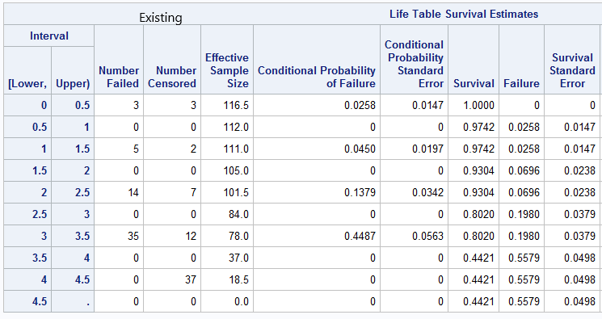

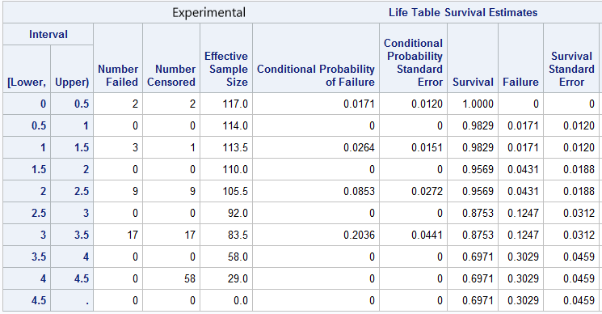

Existing

| Interval | Survival Probability | Standard Error |
| --- | --- | --- |
| 0-6 | 0.974 | 0.015 |
| 6-12 | 0.930 | 0.024 |
| 12-18 | 0.802 | 0.038 |
| 18-24 | 0.442 | 0.050 |

Experimental

| Interval | Survival Probability | Standard Error |
| --- | --- | --- |
| 0-6 | 0.983 | 0.012 |
| 6-12 | 0.957 | 0.019 |
| 12-18 | 0.875 | 0.031 |
| 18-24 | 0.697 | 0.046 |

# Problem 2

## part a

Mathematically specify the structure of the model that includes main effects for treatment and time, as well as their interaction. Mathematically define all variables used in the model

```r
nonex=c(112,105,84,37)
failex=c(3,5,14,35)
wdex=c(3,2,7,12)
ptex=6*(nonex+.5*failex+.5*wdex)
ptex
```

```
## [1] 690 651 567 363
```

```r
nonep=c(114,110,92,58)
failep=c(2,3,9,17)
wdep=c(2,1,9,17)
ptep=6*(nonep+.5*failep+.5*wdep)
ptep
```

```
## [1] 696 672 606 450
```

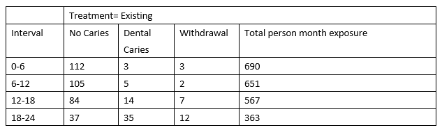

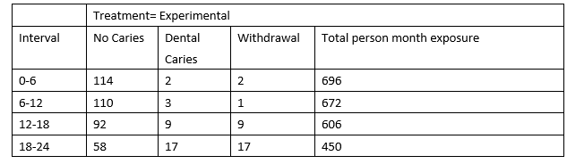

**Assumptions**:

- Withdrawals are uniformly distributed during time intervals in which they occur and are unrelated to treatment failures
- Within-interval probabilities of treatment failures are small. Time-to-failure events have independent exponential distributions

$logit(\lambda/n)=\alpha+\beta_1 X_1+\beta_2 X_2+\beta_3 X_3+\beta_4 X_4+\beta_5 X_5+\beta_6 X_6+\beta_7 X_7$

where $\lambda$ is the number of caries and n is the person-months of exposure

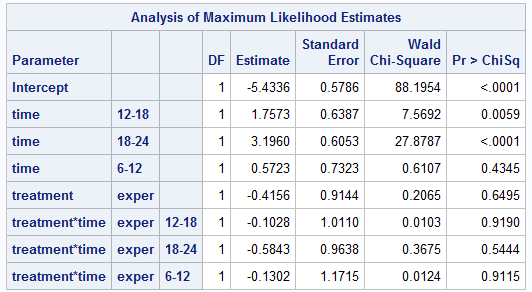

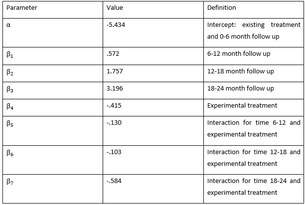

## part b

Fit the model you specified in (a) and assess the effect of interaction between treatment and time.

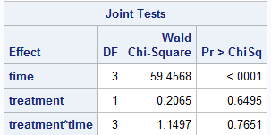

$H_0: \beta_5=\beta_6=\beta_7$ The interaction between treatment and time is nonsignificant

Wald $\chi^2=1.15$ df=3 p-value$=.765>.05$ Fail to reject $H_0$ and conclude that the interaction between treatment and time is not significant.

## part c

Regardless of your conclusion from part (b), fit the main effects model (i.e., the model without interaction terms) for treatment and follow-up period.

### i)

Interpret the model parameters.

$logit(\lambda/n)=\alpha+\beta_1 X_1+\beta_2 X_2+\beta_3 X_3+\beta_4 X_4$

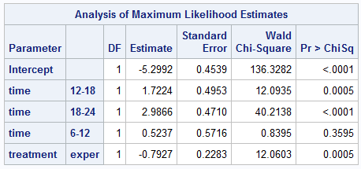

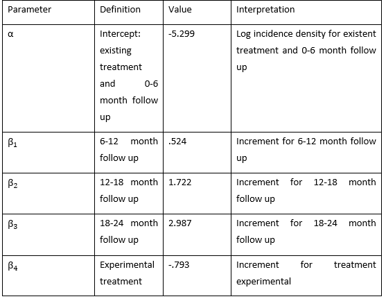

### ii)

Provide a 95% confidence interval for the model parameter corresponding to the treatment variable.

```r
c(-.7917-1.96*.2283,-.7917+1.96*.2283)
```

```
## [1] -1.239168 -0.344232
```

$\hat{\beta_4}=-.793$ $se=.2283$

95% CI: $(-1.239,-.344)$

## part d

For each treatment group, provide model-predicted values using the model in part (c) for cumulative probabilities of no occurrence of dental caries by 6 months, 12 months, 18 months, and 24 months, respectively.

**Cumulative probabilities of no occurrence of a cavity**

[output not shown]

# Problem 3

## part a

Fit a GEE repeated measures logistic regression model across all study follow-up visits (not including at the time of randomization) to describe the marginal relationship of participants’ self-rating of good health to the main effects of randomized group, visit (as a class variable), health self-rating at time of randomization, and age group as explanatory variables together with group by visit interaction. Use 15-24 year old women in the control group with a good health assessment at randomization as your reference group, and use 3 months post- randomization as your reference visit. Specify an exchangeable working correlation structure.

$y_{ij}$ denotes the response from subject i at time j

Assuming an exhangeable working correlation structure:

$R_{i}(\alpha)$ is the working correlation matrix, which may depend on a vector of unknown parameters $\alpha$ which is the same for all subjects.

$$Corr(Y_{ij},Y_{ij'})=\begin{cases} 1 \quad j=j'\\
\alpha \quad j\neq j' \end{cases}$$

### i)

Assess goodness of fit through consideration of other pairwise interactions between explanatory variables in the model. Also assess whether group by visit needs to remain in the model.

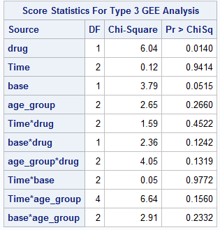

Assessing goodness of fit through consideration of other pairwise interactions between explanatory variables

Model= drug time base age_group drugxtime drug*base drug*age_group time*base time*age_group base*age_group

The Score statistics for Type 3 GEE Analysis Tests show that none of the interaction terms are significant

$\alpha=.05$

time*drug

base*drug

age_group*drug

time*base

Conclusion: no significant interaction terms

Assessing whether time*age_group interaction should be in the model

Model=drug time base age_group time*age_group

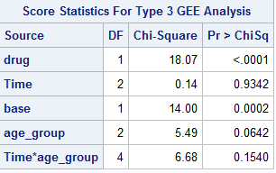

Score statistics for Type 3 GEE Analysis Test

time*age_group

Based on this result we will not include time*age_group in the model

Our final model is:

model = drug time base age_group

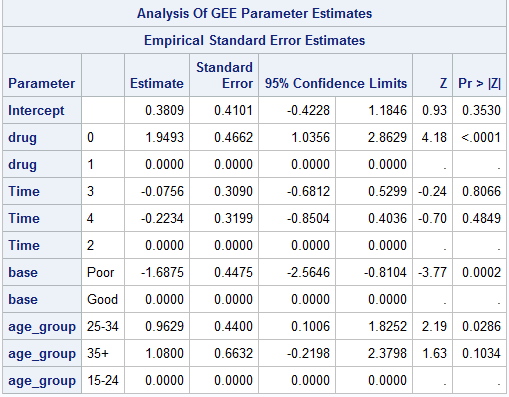

### ii)

Do the results of i) affect your choice for the final model? Explain in 1-2 sentences.

The interaction terms were non significant thus we have no interaction terms in our final model. Therefore the results from the first part affect the choice for the final model.

### iii)

For the final model based on ii), present the table of parameter estimates, along with a standard error, test statistic, and p-value for each.

[figure not shown]

reference group: age_group=15-24, drug=1 (placebo), time=2, base=good

## part b

Using your final recommended model from part (a), separately for each follow up visit, provide the odds ratio and corresponding 95% confidence interval that pertains to the intervention effect as estimated by the model for that visit.

$\alpha$=intercept

$\beta_1$ = treatment drug

$\beta_2$ = time 3

$\beta_3$ = time 4

Odds Ratio comparing treatment effect for time 2

$\exp(\alpha_1+\beta_1)/\exp(\alpha_1)=\exp(\beta_1)=\exp(1.949)=7.022$

Odds Ratio comparing treatment effect for time 3

$\exp(\alpha_1+\beta_1+\beta_2)/\exp(\alpha_1+\beta_2)=\exp(\beta_1)=\exp(1.949)=7.022$

Odds Ratio comparing treatment effect for time 4

$\exp(\alpha_1+\beta_1+\beta_3)/\exp(\alpha_1+\beta_3)=\exp(\beta_1)=\exp(1.949)=7.022$